# McNally et al. Larval Biomineralization

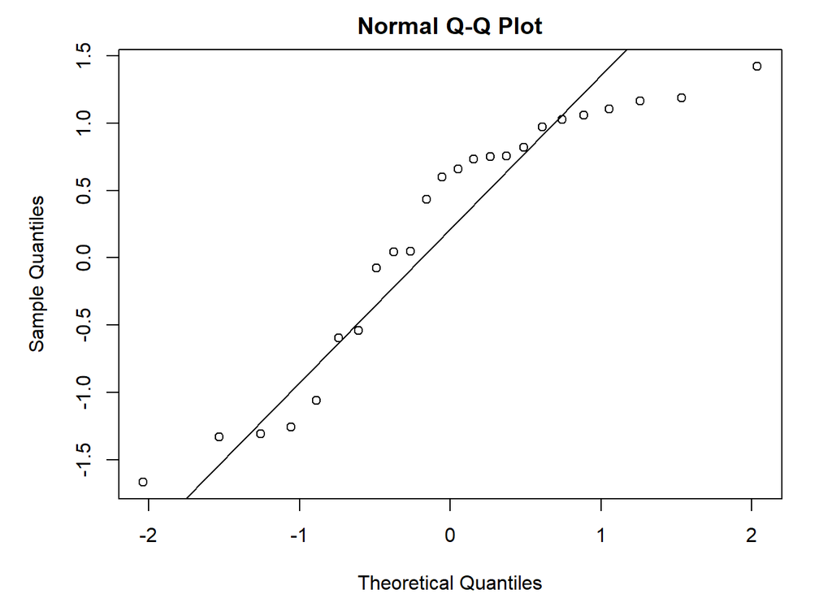

```r
qqnorm(ConFams$MeanGPDExp)
qqline(ConFams$MeanGPDExp)
```

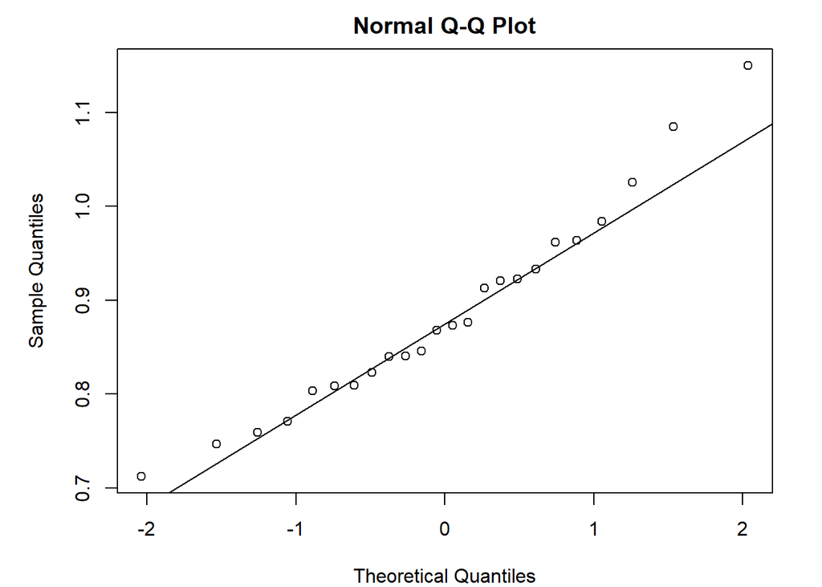

```r
qqnorm(ConFams$RatSurv)
qqline(ConFams$RatSurv)
```

```r
EPmod2<- lmer(RatSurv~MeanGPDCon*ParentTrt+(1|FemaleID)+(1|MaleID), data=SurvWideDat)
```

```
## boundary (singular) fit: see ?isSingular
```

```r
EPmod2Step<- step(EPmod2)
```

```
## boundary (singular) fit: see ?isSingular
```

```r
print(EPmod2Step)
```

```
## Backward reduced random-effect table:
##
##                Eliminated npar logLik     AIC    LRT Df Pr(>Chisq)
## <none>                       7 29.602 -45.205
## (1 | MaleID)            1    6 29.602 -47.205 0.0000  1    1.00000
## (1 | FemaleID)          0    5 26.860 -43.720 5.4847  1    0.01918 *
## ---
## Signif. codes:  0 '***' 0.001 '**' 0.01 '*' 0.05 '.' 0.1 ' ' 1
##
## Backward reduced fixed-effect table:
## Degrees of freedom method: Satterthwaite
##
##                      Eliminated    Sum Sq   Mean Sq NumDF  DenDF F value Pr(>F)
## MeanGPDCon:ParentTrt          1 0.0125236 0.0125236     1 27.135  1.6129 0.2149
## MeanGPDCon                    2 0.0000371 0.0000371     1 24.809  0.0046 0.9463
## ParentTrt                     3 0.0008334 0.0008334     1 13.000  0.1049 0.7512
##
## Model found:
## RatSurv ~ (1 | FemaleID)
```

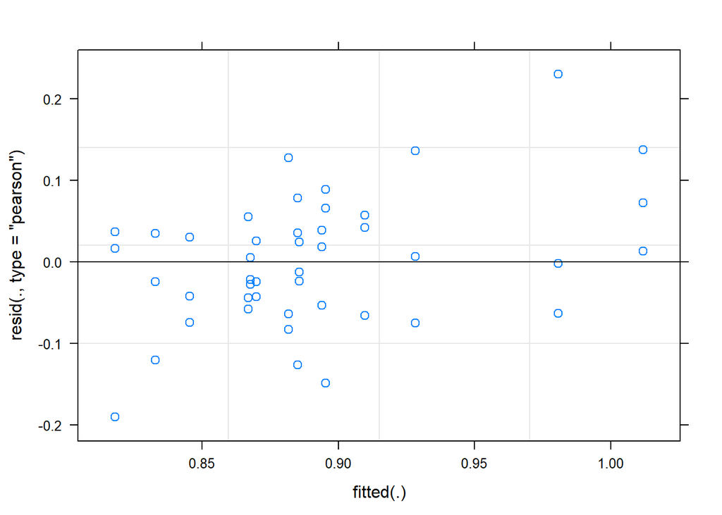

```r
EPmod2fin<- lmer(RatSurv~ (1|FemaleID), data=SurvWideDat)
plot(EPmod2fin)
```

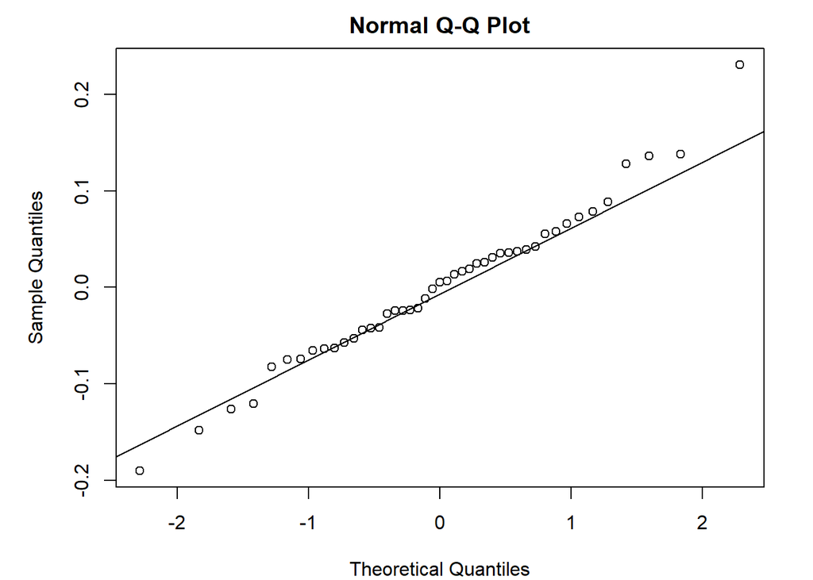

```r
qqnorm(resid(EPmod2fin))
qqline(resid(EPmod2fin))
```

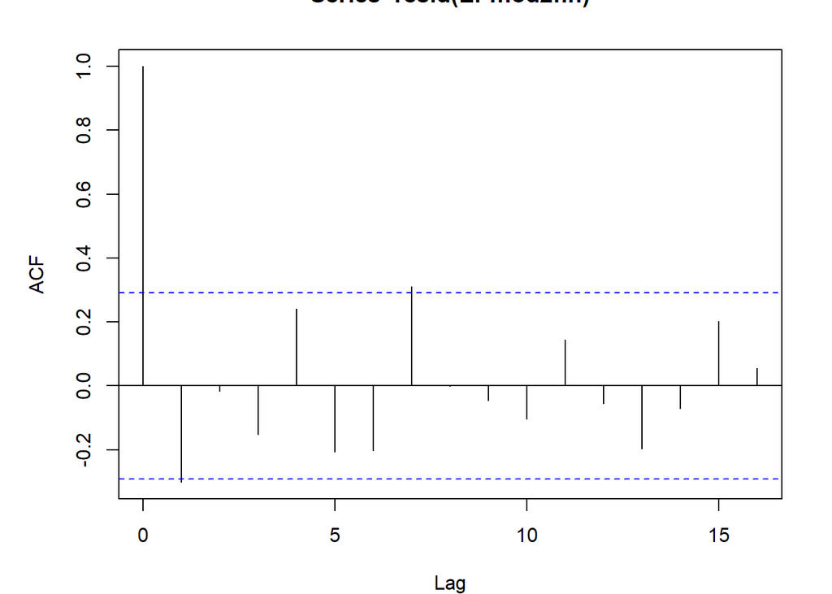

```r
acf(resid(EPmod2fin))
```

```r
summary(EPmod2fin)
```

```
## Linear mixed model fit by REML. t-tests use Satterthwaite's method [
## lmerModLmerTest]
## Formula: RatSurv ~ (1 | FemaleID)
##    Data: SurvWideDat
##
## REML criterion at convergence: -70.6
##
## Scaled residuals:
##      Min       1Q   Median       3Q      Max
## -2.13302 -0.59697  0.05766  0.43674  2.58749
##
## Random effects:
##  Groups   Name        Variance Std.Dev.
##  FemaleID (Intercept) 0.004272 0.06536
##  Residual             0.007948 0.08915
## Number of obs: 45, groups:  FemaleID, 15
##
## Fixed effects:
##             Estimate Std. Error       df t value Pr(>|t|)
## (Intercept)  0.89152    0.02148 14.00000    41.5 4.65e-16 ***
## ---
## Signif. codes:  0 '***' 0.001 '**' 0.01 '*' 0.05 '.' 0.1 ' ' 1
```

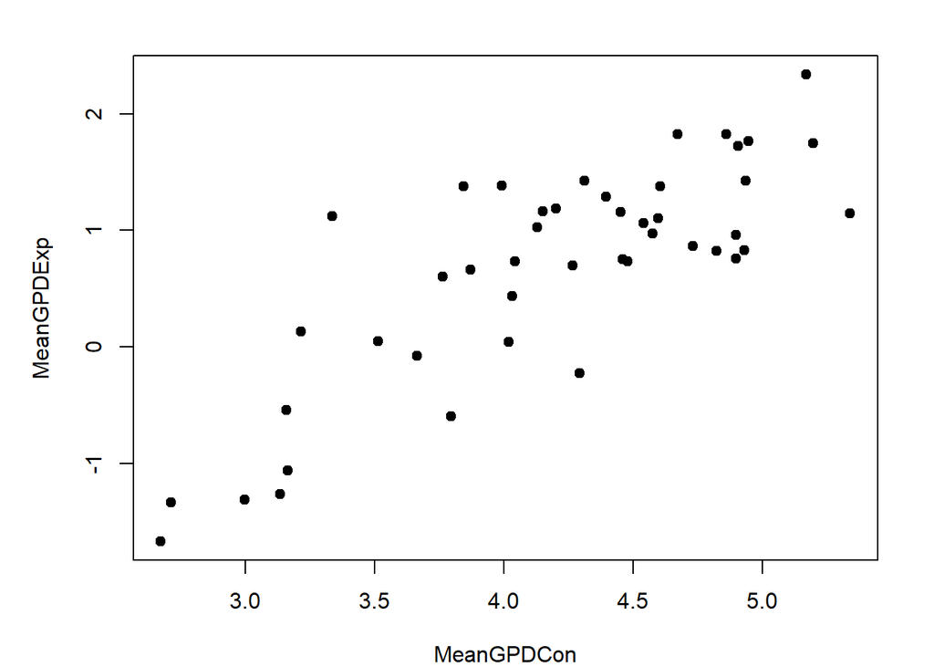

```r
plot(MeanGPDExp~MeanGPDCon, data=SurvWideDat, pch=19)
```

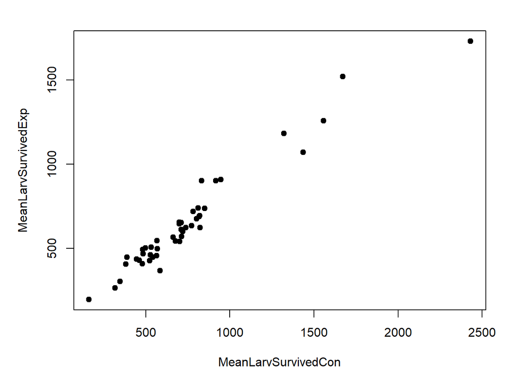

```r
plot(MeanLarvSurvivedExp~MeanLarvSurvivedCon, data=SurvWideDat, pch=19)
```

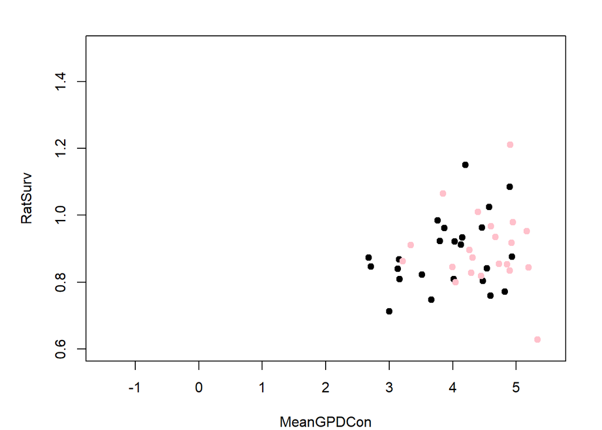

```r
plot(RatSurv~MeanGPDCon, data=ConFams, pch=19, xlim=c(-1.5, 5.5), ylim=c(0.6, 1.5))
points(RatSurv~MeanGPDCon, data=ExpFams, pch=19, col="pink")
```

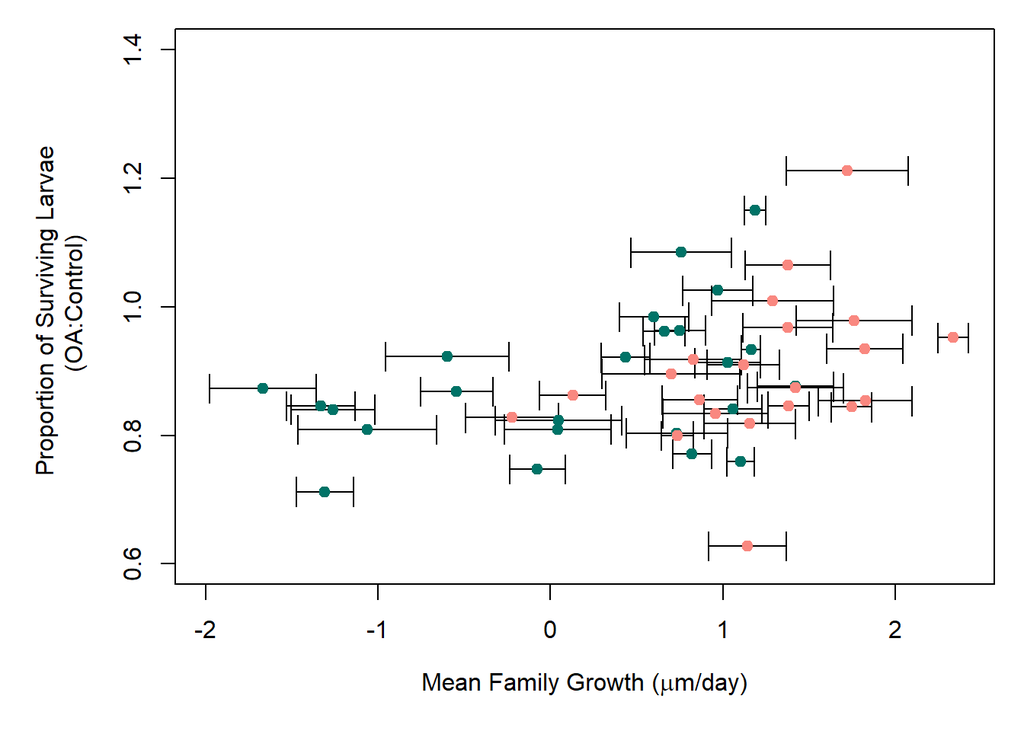

```r
par(mar=c(5,6,1,1), mfrow=c(1,1))
plot(RatSurv~MeanGPDExp, data=ConFams, pch=19, col="#007367", xlim=c(-2, 2.4), ylim=c(0.6, 1.4), xlab= expression(paste("Mean Family Growth (", mu, "m/day)")), ylab="Proportion of Surviving Larvae \n (OA:Control)")
arrows(x0=(SurvWideDat$MeanGPDExp-SurvWideDat$SEMeanGPDCExp), x1= (SurvWideDat$MeanGPDExp+SurvWideDat$SEMeanGPDCExp), y0 = SurvWideDat$RatSurv, y1= SurvWideDat$RatSurv, code=3, angle=90, len=.1)
points(RatSurv~MeanGPDExp, data=ConFams, pch=19, col="#007367")
points(RatSurv~MeanGPDExp, data=ExpFams, pch=19, col="#F98880")
par(xpd=TRUE)
legend.enhanced("topright",
   c("Control", "OA-exposed"),
   pch=19,
   col=c("#007367","#F98880"),
   bty="n",
   title="Parent Treatment",
   horiz=TRUE,
   y.intersp=.7,
   x.intersp=0.5,
   title.adj=c(.5,0),
   title.col="black",
   seg.len =1,
   cex=.7,
   yjust=0.5,
   text.font = NULL,
   inset = c(0,-.15)
   )
```

## look at egg size vs. growth per day

```r
#get data just in exposed larvae conditions for control parents
ExpLarConParByJar<- subset(LarvByJarDatConParents, JarTrt=="Exposed")
ExpLarExpParByJar<- subset(LarvByJarDatExpParents, JarTrt=="Exposed")
Eggmodlm<- lmodel2(MeanGPD~EggDiamum, data=ExpLarConParByJar, nperm=1000)
```

```
## RMA was not requested: it will not be computed.
```

```r
Eggmodlmsimp<- lm(MeanGPD~1, data=ExpLarConParByJar)
par(mfcol=c(2,2))
plot(Eggmodlm)
Eggmodlmexp<- lmodel2(MeanGPD~EggDiamum, data=ExpLarExpParByJar, nperm=1000)
```

```
## RMA was not requested: it will not be computed.
```

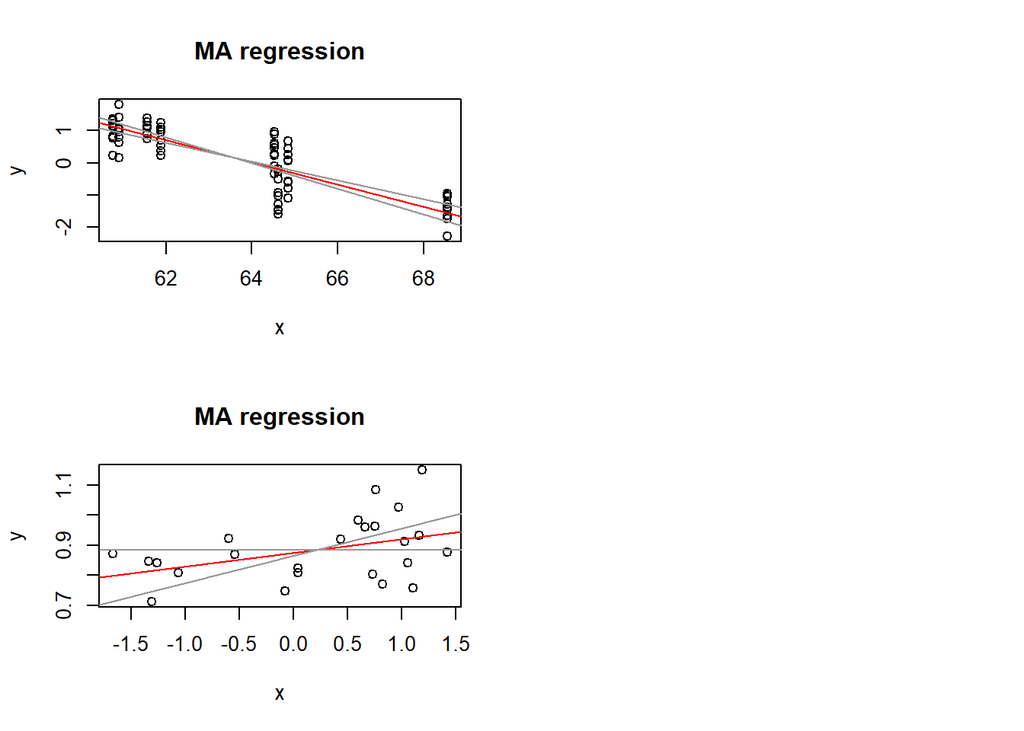

```r
Eggmodlmexpsimp<- lm(MeanGPD~1, data=ExpLarExpParByJar)

plot(EPmodlmcon)
par(mfcol=c(1,1), xpd=FALSE)
```

```r
Eggmodlm
```

```
##
## Model II regression
##
## Call: lmodel2(formula = MeanGPD ~ EggDiamum, data = ExpLarConParByJar,
## nperm = 1000)
##
## n = 72   r = -0.833717   r-square = 0.695084
## Parametric P-values:   2-tailed = 1.001202e-19    1-tailed = 5.00601e-20
## Angle between the two OLS regression lines = 7.134807 degrees
##
## Permutation tests of OLS, MA, RMA slopes: 1-tailed, tail corresponding to sign
## A permutation test of r is equivalent to a permutation test of the OLS slope
## P-perm for SMA = NA because the SMA slope cannot be tested
##
## Regression results
##   Method Intercept      Slope Angle (degrees) P-perm (1-tailed)
## 1    OLS  21.15202 -0.3300686       -18.26643       0.000999001
## 2     MA  22.09104 -0.3448659       -19.02757       0.000999001
## 3    SMA  25.32961 -0.3959001       -21.59862                NA
##
## Confidence intervals
##   Method 2.5%-Intercept 97.5%-Intercept 2.5%-Slope 97.5%-Slope
## 1    OLS       17.84242        24.46163 -0.3821817  -0.2779555
## 2     MA       18.68882        25.60955 -0.4003115  -0.2912527
## 3    SMA       22.23929        28.85336 -0.4514283  -0.3472021
##
## Eigenvalues: 7.089885 0.2731198
##
## H statistic used for computing C.I. of MA: 0.002367982
```

```r
Eggmodlmexp
```

```
##
## Model II regression
##
## Call: lmodel2(formula = MeanGPD ~ EggDiamum, data = ExpLarExpParByJar,
## nperm = 1000)
##
## n = 63   r = -0.409103   r-square = 0.1673653
## Parametric P-values:   2-tailed = 0.0008712406    1-tailed = 0.0004356203
## Angle between the two OLS regression lines = 37.88059 degrees
##
## Permutation tests of OLS, MA, RMA slopes: 1-tailed, tail corresponding to sign
## A permutation test of r is equivalent to a permutation test of the OLS slope
## P-perm for SMA = NA because the SMA slope cannot be tested
##
## Regression results
##   Method Intercept      Slope Angle (degrees) P-perm (1-tailed)
## 1    OLS  13.00000 -0.1901530       -10.76643       0.001998002
## 2     MA  15.45444 -0.2297519       -12.93926       0.001998002
## 3    SMA  30.02355 -0.4648046       -24.92922                NA
##
## Confidence intervals
##   Method 2.5%-Intercept 97.5%-Intercept 2.5%-Slope 97.5%-Slope
## 1    OLS       6.267579        19.73243 -0.2987407 -0.08156518
## 2     MA       7.488285        23.89402 -0.3659130 -0.10122893
## 3    SMA      24.068773        37.52982 -0.5859080 -0.36873244
##
## Eigenvalues: 2.303283 0.3803656
##
## H statistic used for computing C.I. of MA: 0.0155308
```

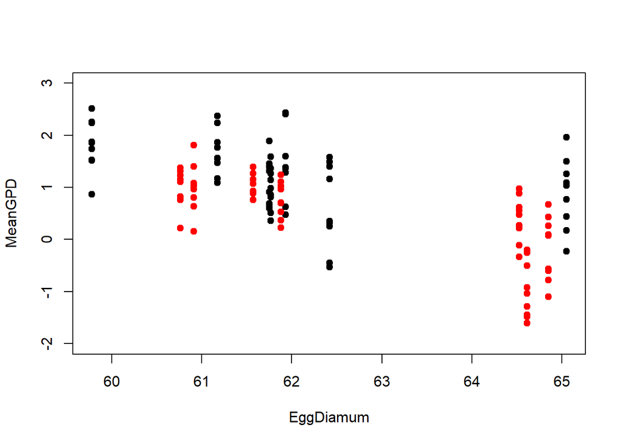

```r
#plot the egg diameter and growth per day data
plot(MeanGPD~EggDiamum, data=ExpLarExpParByJar, ylim=c(-2, 3), pch=19)
points(MeanGPD~EggDiamum, data=ExpLarConParByJar, pch=19, col="red")
```

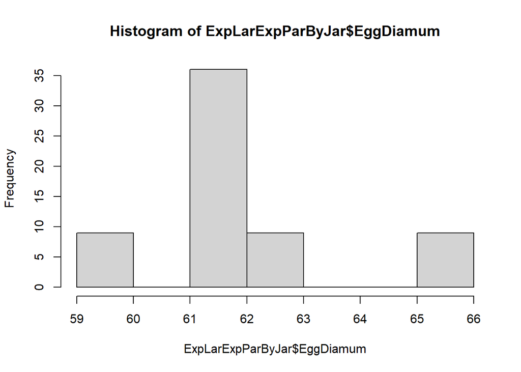

```r
hist(ExpLarExpParByJar$EggDiamum)
```

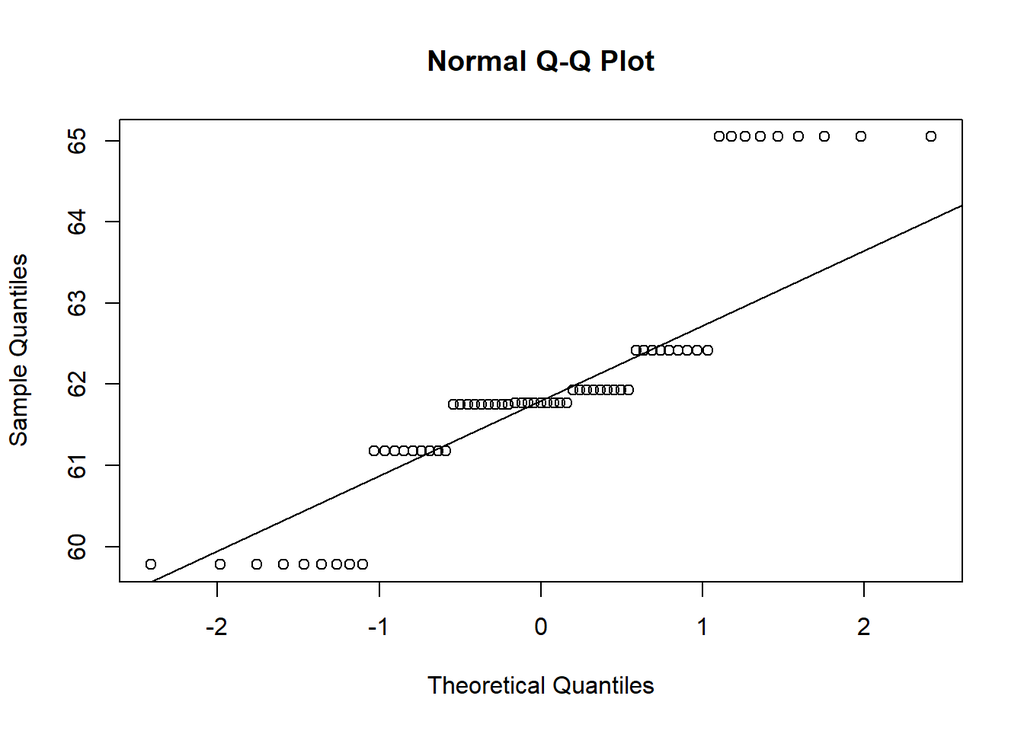

```r
qqnorm(ExpLarExpParByJar$EggDiamum)
qqline(ExpLarExpParByJar$EggDiamum)
```

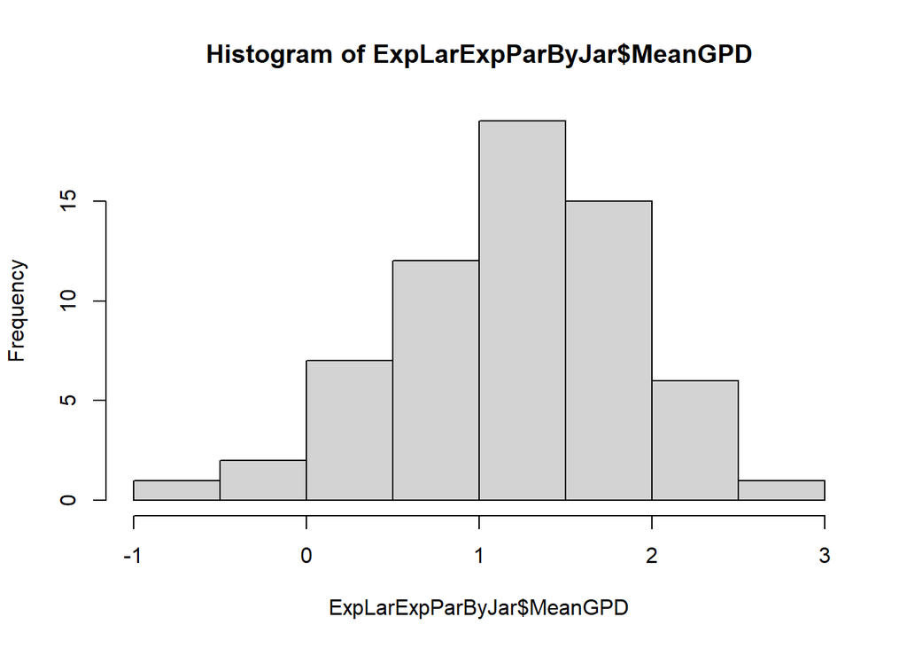

```r
hist(ExpLarExpParByJar$MeanGPD)
```

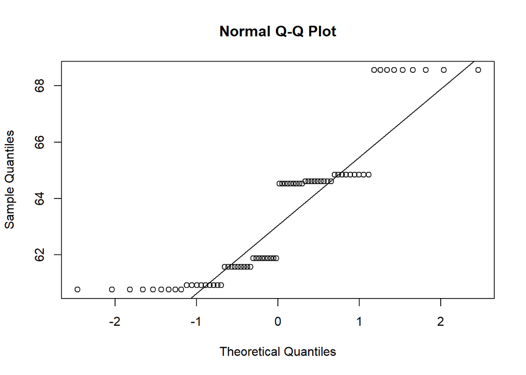

```r
qqnorm(ExpLarConParByJar$EggDiamum)
qqline(ExpLarConParByJar$EggDiamum)
```

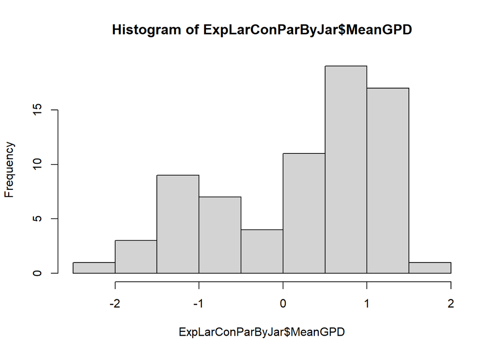

```r
hist(ExpLarConParByJar$MeanGPD)
```

Do simple t-tests on the means for oa-exposed and control exposed parents within each larvae treatment

```r
#get Bonferoni adjusted p-crit:
0.05/10
```

```
## [1] 0.005
```

```r
Lexp<- subset(LarvaeDat, JarTrt=="Exposed")
Lcon<- subset(LarvaeDat, JarTrt=="Control")

t.test(GrowthPerDay~ParentTrt, data=Lexp, var.equal=TRUE)
```

```
##
##  Two Sample t-test
##
## data:  GrowthPerDay by ParentTrt
## t = 14.097, df = 1346, p-value < 2.2e-16
## alternative hypothesis: true difference in means is not equal to 0
## 95 percent confidence interval:
##  0.8667179 1.1469320
## sample estimates:
## mean in group 2600  mean in group 400
##           1.213118           0.206293
```

```r
t.test(GrowthPerDay~ParentTrt, data=Lcon, var.equal=TRUE)
```

```
##
##  Two Sample t-test
##
## data:  GrowthPerDay by ParentTrt
## t = 10.005, df = 1348, p-value < 2.2e-16
## alternative hypothesis: true difference in means is not equal to 0
## 95 percent confidence interval:
##  0.4553516 0.6774651
## sample estimates:
## mean in group 2600  mean in group 400
##           4.494797           3.928388
```

```r
t.test(LarvaeDiamum~ParentTrt, data=Lexp, var.equal=TRUE)
```

```
##
##  Two Sample t-test
##
## data:  LarvaeDiamum by ParentTrt
## t = 8.1796, df = 1346, p-value = 6.522e-16
## alternative hypothesis: true difference in means is not equal to 0
## 95 percent confidence interval:
##  1.174311 1.915293
## sample estimates:
## mean in group 2600  mean in group 400
##            65.6224            64.0776
```

```r
t.test(LarvaeDiamum~ParentTrt, data=Lcon, var.equal=TRUE)#not significantly different for control larvae
```

```
##
##  Two Sample t-test
##
## data:  LarvaeDiamum by ParentTrt
## t = 1.4748, df = 1348, p-value = 0.1405
## alternative hypothesis: true difference in means is not equal to 0
## 95 percent confidence interval:
##  -0.07356676  0.51920840
## sample estimates:
## mean in group 2600  mean in group 400
##           75.46671           75.24389
```

```r
t.test(sqrt(LarvaeAreaum2)~ParentTrt, data=Lexp, var.equal=TRUE)
```

```
##
##  Two Sample t-test
##
## data:  sqrt(LarvaeAreaum2) by ParentTrt
## t = 7.0498, df = 1346, p-value = 2.855e-12
## alternative hypothesis: true difference in means is not equal to 0
## 95 percent confidence interval:
##  0.7557342 1.3384891
## sample estimates:
## mean in group 2600  mean in group 400
##           53.63310           52.58599
```

```r
t.test(sqrt(LarvaeAreaum2)~ParentTrt, data=Lcon, var.equal=TRUE) #not significantly different for control larvae
```

```
##
##  Two Sample t-test
##
## data:  sqrt(LarvaeAreaum2) by ParentTrt
## t = 1.483, df = 1348, p-value = 0.1383
## alternative hypothesis: true difference in means is not equal to 0
## 95 percent confidence interval:
##  -0.06172545  0.44418997
## sample estimates:
## mean in group 2600  mean in group 400
##           62.40781           62.21658
```

```r
t.test(LarvaePerimeterum~ParentTrt, data=Lexp, var.equal=TRUE)
```

```
##
##  Two Sample t-test
##
## data:  LarvaePerimeterum by ParentTrt
## t = 7.1895, df = 1346, p-value = 1.075e-12
## alternative hypothesis: true difference in means is not equal to 0
## 95 percent confidence interval:
##  2.917762 5.107556
## sample estimates:
## mean in group 2600  mean in group 400
##           203.5199           199.5072
```

```r
t.test(LarvaePerimeterum~ParentTrt, data=Lcon, var.equal=TRUE) #not significantly different for control larvae
```

```
##
##  Two Sample t-test
##
## data:  LarvaePerimeterum by ParentTrt
## t = 1.2371, df = 1348, p-value = 0.2163
## alternative hypothesis: true difference in means is not equal to 0
## 95 percent confidence interval:
##  -0.3601831  1.5899445
## sample estimates:
## mean in group 2600  mean in group 400
##           236.9926           236.3777
```

```r
t.test(PerimLenRat~ParentTrt, data=Lexp, var.equal=TRUE)
```

```
##
##  Two Sample t-test
##
## data:  PerimLenRat by ParentTrt
## t = -3.936, df = 1346, p-value = 8.71e-05
## alternative hypothesis: true difference in means is not equal to 0
## 95 percent confidence interval:
##  -0.017865978 -0.005980582
## sample estimates:
## mean in group 2600  mean in group 400
##           3.102418           3.114341
```

```r
t.test(PerimLenRat~ParentTrt, data=Lcon, var.equal=TRUE)#not significantly different for control larvae
```

```
##
##  Two Sample t-test
##
## data:  PerimLenRat by ParentTrt
## t = -0.47893, df = 1348, p-value = 0.6321
## alternative hypothesis: true difference in means is not equal to 0
## 95 percent confidence interval:
##  -0.005393581  0.003276831
## sample estimates:
## mean in group 2600  mean in group 400
##           3.140449           3.141508
```

## Protocol versions check

Run survival model with just the data for protocol 1 and then just the data from protocol 2 and compare the results to the actual output. Steps: 1) subset the data by protocol 2) get Sfams for prot 1 and prot 2 data 3) run the survival analysis

```r
#1 subset the data by protocol
Prot1<- subset(LarvByJarDat, ProtocolVersion == "1")
Prot2<- subset(LarvByJarDat, ProtocolVersion != "1")

SurvDatProt1<- ddply(Prot1, .(CrossID, ParentTrt, JarTrt, MaleID, FemaleID, TrtTankID,MaleTrtTankID, AccTankID, Block), numcolwise(mean, na.rm=TRUE))
SESurvDatProt1<- ddply(Prot1, .(CrossID, ParentTrt, JarTrt, Block), numcolwise(se, na.rm=TRUE)) #get the standard errors for each mean count
SESurvDatProt1<- subset(SESurvDatProt1, select= c(CrossID, JarTrt, LarvaeSurvived, SatArag_ATDIC, JarSatArg_Total, MeanGPD)) #select only certain columns.
colnames(SESurvDatProt1)<- paste("SE", colnames(SESurvDatProt1), sep="")
#merge the standard error data to the SurvDat dataframe
SurvDatProt1<- merge(SurvDatProt1, SESurvDatProt1, by.x= c("CrossID", "JarTrt"), by.y= c("SECrossID", "SEJarTrt"))
#only keep the relevant fields because otherwise this is a huge data frame
SurvDatProt1<- subset(SurvDatProt1, select= c(CrossID, JarTrt, ParentTrt, MaleID, FemaleID, TrtTankID,MaleTrtTankID, AccTankID, LarvaeSurvived, Block, SELarvaeSurvived, SatArag_ATDIC, MeanGPD, SEMeanGPD))
SurvDatProt1<- subset(SurvDatProt1, Block=="B1" & CrossID !="")
#use the spread function to go from long form to wide form for the survival data

SurvDatToWideProt1<- unite(SurvDatProt1, Value, c(LarvaeSurvived, SELarvaeSurvived, MeanGPD, SEMeanGPD), sep="_")
SurvWideDatProt1<- spread(SurvDatToWideProt1, JarTrt, value= Value)
#now split the mean and SE apart again
SurvWideDatProt1<- separate(SurvWideDatProt1, Control, into= c("MeanLarvSurvivedCon", "SELarvSurvivedCon", "MeanGPDCon", "SEMeanGPDCon"), sep="_")
SurvWideDatProt1<- separate(SurvWideDatProt1, Exposed, into= c("MeanLarvSurvivedExp", "SELarvSurvivedExp", "MeanGPDExp", "SEMeanGPDCExp"), sep="_")
#make the means and ses numeric
SurvWideDatProt1$MeanLarvSurvivedExp<- as.numeric(SurvWideDatProt1$MeanLarvSurvivedExp)
SurvWideDatProt1$MeanLarvSurvivedCon<- as.numeric(SurvWideDatProt1$MeanLarvSurvivedCon)
SurvWideDatProt1$SELarvSurvivedExp<- as.numeric(SurvWideDatProt1$SELarvSurvivedExp)
SurvWideDatProt1$SELarvSurvivedCon<- as.numeric(SurvWideDatProt1$SELarvSurvivedCon)
SurvWideDatProt1$MeanGPDCon<- as.numeric(SurvWideDatProt1$MeanGPDCon)
SurvWideDatProt1$MeanGPDExp<- as.numeric(SurvWideDatProt1$MeanGPDExp)
SurvWideDatProt1$SEMeanGPDCon<- as.numeric(SurvWideDatProt1$SEMeanGPDCon)
SurvWideDatProt1$SEMeanGPDCExp<- as.numeric(SurvWideDatProt1$SEMeanGPDCExp)
SurvWideDatProt1$RatSurv<- SurvWideDatProt1$MeanLarvSurvivedExp/SurvWideDatProt1$MeanLarvSurvivedCon
SurvWideDatProt1$RatGPD<- SurvWideDatProt1$MeanGPDExp/SurvWideDatProt1$MeanGPDCon
SurvWideDatProt1$SurvChange<- (SurvWideDatProt1$MeanLarvSurvivedCon-SurvWideDatProt1$MeanLarvSurvivedExp)/SurvWideDatProt1$MeanLarvSurvivedCon
SurvWideDatProt1$CrossID<- as.factor(SurvWideDatProt1$CrossID)
SurvWideDatProt1$FemaleID<- as.factor(SurvWideDatProt1$FemaleID)
SurvWideDatProt1$MaleID<- as.factor(SurvWideDatProt1$MaleID)

SurvDatProt2<- ddply(Prot2, .(CrossID, ParentTrt, JarTrt, MaleID, FemaleID, TrtTankID,MaleTrtTankID, AccTankID, Block), numcolwise(mean, na.rm=TRUE))
SESurvDatProt2<- ddply(Prot2, .(CrossID, ParentTrt, JarTrt, Block), numcolwise(se, na.rm=TRUE)) #get the standard errors for each mean count
SESurvDatProt2<- subset(SESurvDatProt2, select= c(CrossID, JarTrt, LarvaeSurvived, SatArag_ATDIC, JarSatArg_Total, MeanGPD)) #select only certain columns.
colnames(SESurvDatProt2)<- paste("SE", colnames(SESurvDatProt2), sep="")
#merge the standard error data to the SurvDat dataframe
SurvDatProt2<- merge(SurvDatProt2, SESurvDatProt2, by.x= c("CrossID", "JarTrt"), by.y= c("SECrossID", "SEJarTrt"))
#only keep the relevant fields because otherwise this is a huge data frame
SurvDatProt2<- subset(SurvDatProt2, select= c(CrossID, JarTrt, ParentTrt, MaleID, FemaleID, TrtTankID,MaleTrtTankID, AccTankID, LarvaeSurvived, Block, SELarvaeSurvived, SatArag_ATDIC, MeanGPD, SEMeanGPD))
SurvDatProt2<- subset(SurvDatProt2, Block=="B1" & CrossID !="")
#use the spread function to go from long form to wide form for the survival data

SurvDatToWideProt2<- unite(SurvDatProt2, Value, c(LarvaeSurvived, SELarvaeSurvived, MeanGPD, SEMeanGPD), sep="_")
SurvWideDatProt2<- spread(SurvDatToWideProt2, JarTrt, value= Value)
#now split the mean and SE apart again
SurvWideDatProt2<- separate(SurvWideDatProt2, Control, into= c("MeanLarvSurvivedCon", "SELarvSurvivedCon", "MeanGPDCon", "SEMeanGPDCon"), sep="_")
SurvWideDatProt2<- separate(SurvWideDatProt2, Exposed, into= c("MeanLarvSurvivedExp", "SELarvSurvivedExp", "MeanGPDExp", "SEMeanGPDCExp"), sep="_")
#make the means and ses numeric
SurvWideDatProt2$MeanLarvSurvivedExp<- as.numeric(SurvWideDatProt2$MeanLarvSurvivedExp)
SurvWideDatProt2$MeanLarvSurvivedCon<- as.numeric(SurvWideDatProt2$MeanLarvSurvivedCon)
SurvWideDatProt2$SELarvSurvivedExp<- as.numeric(SurvWideDatProt2$SELarvSurvivedExp)
SurvWideDatProt2$SELarvSurvivedCon<- as.numeric(SurvWideDatProt2$SELarvSurvivedCon)
SurvWideDatProt2$MeanGPDCon<- as.numeric(SurvWideDatProt2$MeanGPDCon)
SurvWideDatProt2$MeanGPDExp<- as.numeric(SurvWideDatProt2$MeanGPDExp)
SurvWideDatProt2$SEMeanGPDCon<- as.numeric(SurvWideDatProt2$SEMeanGPDCon)
SurvWideDatProt2$SEMeanGPDCExp<- as.numeric(SurvWideDatProt2$SEMeanGPDCExp)
SurvWideDatProt2$RatSurv<- SurvWideDatProt2$MeanLarvSurvivedExp/SurvWideDatProt2$MeanLarvSurvivedCon
SurvWideDatProt2$RatGPD<- SurvWideDatProt2$MeanGPDExp/SurvWideDatProt2$MeanGPDCon
SurvWideDatProt2$SurvChange<- (SurvWideDatProt2$MeanLarvSurvivedCon-SurvWideDatProt2$MeanLarvSurvivedExp)/SurvWideDatProt2$MeanLarvSurvivedCon
SurvWideDatProt2$CrossID<- as.factor(SurvWideDatProt2$CrossID)
SurvWideDatProt2$FemaleID<- as.factor(SurvWideDatProt2$FemaleID)
SurvWideDatProt2$MaleID<- as.factor(SurvWideDatProt2$MaleID)

#stats on protocol 1 data
par(mfcol=c(1,1))
surv1_prot1<- lmer(RatSurv~ParentTrt+ (1|FemaleID)+(1|MaleID)+(1|TrtTankID)+(1|MaleTrtTankID), data=SurvWideDatProt1)
```

```
## boundary (singular) fit: see ?isSingular
```

```r
survstepFE_prot1<- step(surv1_prot1)
```

```
## boundary (singular) fit: see ?isSingular
## boundary (singular) fit: see ?isSingular
## boundary (singular) fit: see ?isSingular
## boundary (singular) fit: see ?isSingular
```

```r
print(survstepFE_prot1)
```

```
## Backward reduced random-effect table:
##
##                     Eliminated npar logLik     AIC    LRT Df Pr(>Chisq)
## <none>                            7 14.716 -15.432
## (1 | TrtTankID)              1    6 14.716 -17.432 0.0000  1    0.99996
## (1 | MaleTrtTankID)          2    5 14.715 -19.430 0.0011  1    0.97326
## (1 | MaleID)                 3    4 14.440 -20.879 0.5514  1    0.45773
## (1 | FemaleID)               0    3 10.684 -15.367 7.5117  1    0.00613 **
## ---
## Signif. codes:  0 '***' 0.001 '**' 0.01 '*' 0.05 '.' 0.1 ' ' 1
##
## Backward reduced fixed-effect table:
## Degrees of freedom method: Satterthwaite
##
##           Eliminated     Sum Sq    Mean Sq NumDF DenDF F value Pr(>F)
## ParentTrt          1 0.00055147 0.00055147     1    13  0.0308 0.8634
##
## Model found:
## RatSurv ~ (1 | FemaleID)
```

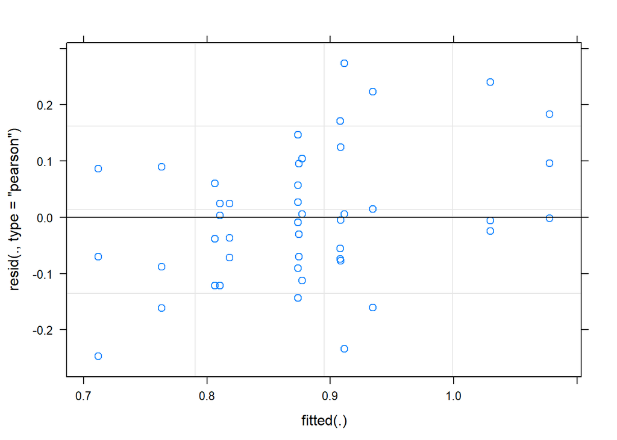

```r
survfin_prot1<- lmer(RatSurv~ (1|FemaleID), data=SurvWideDatProt1)#final model chosen by step function: RatSurv~ (1|FemaleID)
plot(survfin_prot1)
```

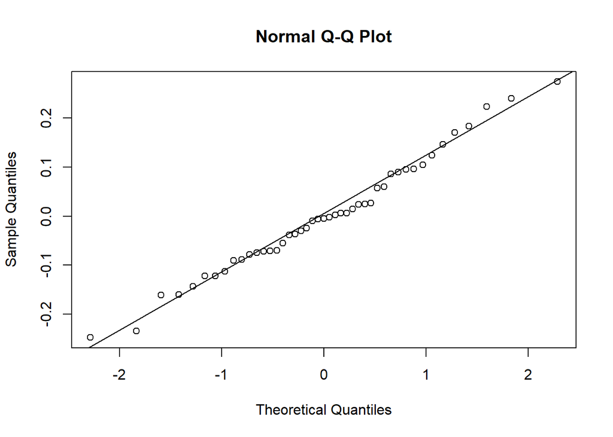

```r
qqnorm(resid(survfin_prot1))
qqline(resid(survfin_prot1))
```

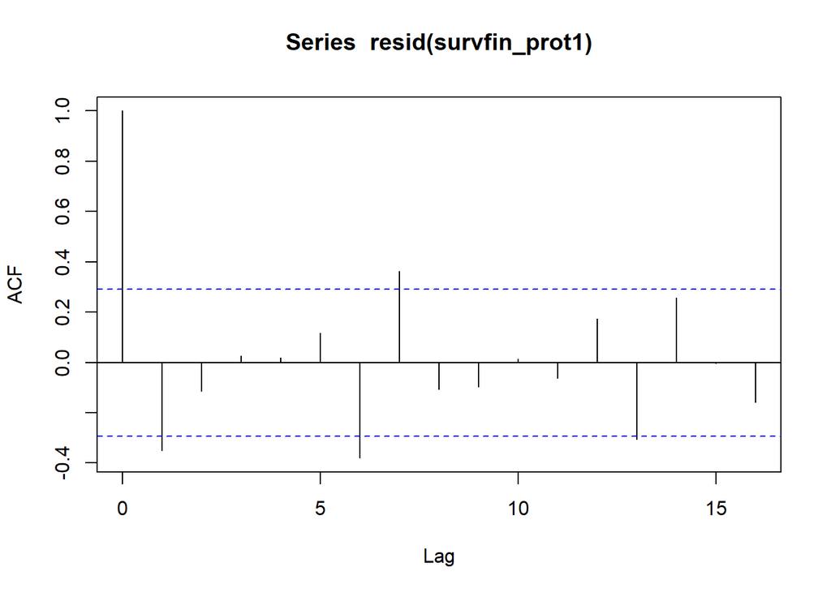

```r
acf(resid(survfin_prot1))
```

```r
summary(survfin_prot1)
```

```
## Linear mixed model fit by REML. t-tests use Satterthwaite's method [
## lmerModLmerTest]
## Formula: RatSurv ~ (1 | FemaleID)
##    Data: SurvWideDatProt1
##
## REML criterion at convergence: -32.3
##
## Scaled residuals:
##      Min       1Q   Median       3Q      Max
## -1.84866 -0.55615 -0.03665  0.64166  2.04720
##
## Random effects:
##  Groups   Name        Variance Std.Dev.
##  FemaleID (Intercept) 0.01285  0.1134
##  Residual             0.01789  0.1338
## Number of obs: 45, groups:  FemaleID, 15
##
## Fixed effects:
##             Estimate Std. Error       df t value Pr(>|t|)
## (Intercept)  0.87861    0.03542 14.00000    24.8 5.71e-13 ***
## ---
## Signif. codes:  0 '***' 0.001 '**' 0.01 '*' 0.05 '.' 0.1 ' ' 1
```

```r
#try to see if this is significantly different for exposed vs control larval treatment
SurvOA_prot1<- subset(SurvWideDatProt1, ParentTrt=="2600")
SurvCon_prot1<- subset(SurvWideDatProt1, ParentTrt=="400")
t.test(SurvOA_prot1$RatSurv, mu = 1, alternative = "two.sided")
```

```
##
##  One Sample t-test
##
## data:  SurvOA_prot1$RatSurv
## t = -3.1831, df = 20, p-value = 0.004673
## alternative hypothesis: true mean is not equal to 1
## 95 percent confidence interval:
##  0.8104679 0.9605365
## sample estimates:
## mean of x
## 0.8855022
```

```r
t.test(SurvCon_prot1$RatSurv, mu = 1, alternative = "two.sided")
```

```
##
##  One Sample t-test
##
## data:  SurvCon_prot1$RatSurv
## t = -3.3854, df = 23, p-value = 0.002547
## alternative hypothesis: true mean is not equal to 1
## 95 percent confidence interval:
##  0.7947252 0.9504412
## sample estimates:
## mean of x
## 0.8725832
```

```r
#stats for protocol 2
par(mfcol=c(1,1))
surv1_Prot2<- lmer(RatSurv~ParentTrt+ (1|FemaleID)+(1|MaleID)+(1|TrtTankID)+(1|MaleTrtTankID), data=SurvWideDatProt2)
```

```
## boundary (singular) fit: see ?isSingular
```

```r
survstepFE_Prot2<- step(surv1_Prot2)
```

[output not shown]

```
## Error in as_lmerModLmerTest(model): model not of class 'lmerMod': cannot coerce to class 'lmerModLmerTest
```

```r
print(survstepFE_Prot2)
```

[output not shown]